# Time Series Forecasting: Analyzing Trends and Predictions with Skforecast

```python
import pandas as pd
import numpy as np
import seaborn as sns
import statsmodels.api as sm
import matplotlib.pyplot as plt
from datetime import datetime
from scipy import stats
from statsmodels.tsa.seasonal import seasonal_decompose
from statsmodels.graphics.tsaplots import plot_acf
from statsmodels.graphics.tsaplots import plot_pacf
```

The columns in the dataset are:

- SETTLEMET_DATA: *date in format dd/mm/yyyy*
- SETTLEMENT_PERIOD: *half hourly period for the historic outtunr occurred*
- ND (National Demand): *National Demand is the sum of metered generation, but excludes generation required to meet station load, pump storage pumping and interconnector exports. National Demand is calculated as a sum of generation based on National Grid ESO operational generation metering. Measured in MW.*
- TSD (Transmission System Demand): *Transmission System Demand is equal to the ND plus the additional generation required to meet station load, pump storage pumping and interconnector exports. Measured in MW.*
- ENGLAND_WALES_DEMAND: *England and Wales Demand, as ND above but on an England and Wales basis. Measured in MW.*
- EMBEDDED_WIND_GENERATION: *This is an estimate of the GB wind generation from wind farms which do not have Transmission System metering installed. These wind farms are embedded in the distribution network and invisible to National Grid ESO. Their effect is to suppress the electricity demand during periods of high wind. The true output of these generators is not known so an estimate is provided based on National Grid ESO’s best model. Measured in MW.*
- EMBEDDED_WIND_CAPACITY: *This is National Grid ESO’s best view of the installed embedded wind capacity in GB. This is based on publicly available information compiled from a variety of sources and is not the definitive view. It is consistent with the generation estimate provided above. Measured in MW*
- EMBEDDED_SOLAR_GENERATION: *This is an estimate of the GB solar generation from PV panels. These are embedded in the distribution network and invisible to National Grid ESO. Their effect is to suppress the electricity demand during periods of high radiation. The true output of these generators is not known so an estimate is provided based on National Grid ESO’s best model. Measured in MW*
- EMBEDDED_SOLAR_CAPACITY: *As embedded wind capacity above, but for solar generation. Measured in MW.*
- NON_BM_STOR (Non-Balancing Mechanism SHort-Term Operating Reserve): *For units that are not included in the ND generator definition. This can be in the form of generation or demand reduction. Measured in MW.*
- PUMP_STORAGE_PUMPING: *The demand due to pumping at hydro pump storage units; the -ve signifies pumping load.*
- IFA_FLOW (IFA Interconnector Flow): *The flow on on the respective interconnector. -ve signifies export power out from GB; +ve signifies import power into GB. Measured in MW.*
- IFA2_FLOW (IFA Interconnector Flow). *The flow on the respective interconnector. -ve signifies export power out from GB; +ve signifies import power into GB. Measured in MW.*
- MOYLE_FLOW (Moyle Interconnector FLow). *The flow on the respective interconnector. -ve signifies export power out from GB; +ve signifies import power into GB. Measured in MW.*
- EAST_WEST_FLOW (East West Innterconnector FLow). *The flow on the respective interconnector. -ve signifies export power out from GB; +ve signifies import power into GB. Measured in MW.*
- NEMO_FLOW (Nemo Interconnector FLow). *The flow on the respective interconnector. -ve signifies export power out from GB; +ve signifies import power into GB. Measured in MW.*
- NSL_FLOW (North Sea Link Interconnector Flow). *The flow on the respective interconnector. -ve signifies export power out from GB; +ve signifies import power into GB. Measured in MW*
- ELCLINK_FLOW. Blank

### Exploratoy Data Analysis (EDA)

```python
#Load data
data = pd.read_csv("./data/historic_demand_2009_2023.csv", index_col=0)
data.info()

print(f'El conjunto de datos presenta un tamaño de {data.shape[0]} filas, {data.shape[1]} columnas y una cantidad de duplicados de {data.duplicated().sum()}')
```

```
<class 'pandas.core.frame.DataFrame'>
Index: 262944 entries, 0 to 262943
Data columns (total 22 columns):
 #   Column                     Non-Null Count   Dtype
---  ------                     --------------   -----
 0   settlement_date            262944 non-null  object
 1   settlement_period          262944 non-null  int64
 2   nd                         262944 non-null  int64
 3   tsd                        262944 non-null  int64
 4   england_wales_demand       262944 non-null  int64
 5   embedded_wind_generation   262944 non-null  int64
 6   embedded_wind_capacity     262944 non-null  int64
 7   embedded_solar_generation  262944 non-null  int64
 8   embedded_solar_capacity    262944 non-null  int64
 9   non_bm_stor                262944 non-null  int64
 10  pump_storage_pumping       262944 non-null  int64
 11  ifa_flow                   262944 non-null  int64
 12  ifa2_flow                  262944 non-null  int64
 13  britned_flow               262944 non-null  int64
 14  moyle_flow                 262944 non-null  int64
 15  east_west_flow             262944 non-null  int64
 16  nemo_flow                  262944 non-null  int64
 17  nsl_flow                   87648 non-null   float64
 18  eleclink_flow              87648 non-null   float64
 19  scottish_transfer          17520 non-null   float64
 20  viking_flow                17520 non-null   float64
 21  is_holiday                 262944 non-null  int64
dtypes: float64(4), int64(17), object(1)
memory usage: 46.1+ MB
El conjunto de datos presenta un tamaño de 262944 filas, 22 columnas y una cantidad de duplicados de 0
```

```python
#we can see that above 50% of total rows is null for 4 fields, so we can obviate it
data.drop(['nsl_flow', "eleclink_flow","scottish_transfer","viking_flow"], axis=1, inplace=True)
```

```python
#2 dataframes, one of these with hours and the another one without it
data_hours = data.copy()
data_hours["settlement_date"] = pd.to_datetime(data_hours["settlement_date"])
data_hours["settlement_period"] = data_hours["settlement_period"]*pd.Timedelta(minutes=30)

data_hours["settlement_date"] = data_hours["settlement_date"] + data_hours["settlement_period"]
data_hours.set_index("settlement_date", inplace=True)
data_hours = data_hours[["nd","tsd"]]

#========================

data["settlement_date"] = pd.to_datetime(data["settlement_date"])
data = data.groupby(["settlement_date"]).sum()
data = data[["nd","tsd"]]
```

```python
data
```

| settlement_date | nd | tsd |
| --- | --- | --- |
| 2009-01-01 | 1789321 | 1849363 |
| 2009-01-02 | 1920721 | 1974406 |
| 2009-01-03 | 1897691 | 1952054 |
| 2009-01-04 | 1911407 | 1968670 |
| 2009-01-05 | 2181646 | 2271471 |
| ... | ... | ... |
| 2023-12-27 | 1218526 | 1344393 |
| 2023-12-28 | 1203899 | 1343649 |
| 2023-12-29 | 1260235 | 1390664 |
| 2023-12-30 | 1272885 | 1337808 |
| 2023-12-31 | 1233635 | 1317885 |

5478 rows × 2 columns

## Supuestos estadísticos principales

### Normalidad

```
Kursotis: -0.3454104130872371
Skewness: 0.22782915253372135
Valores optimos entre -1 y 1
```

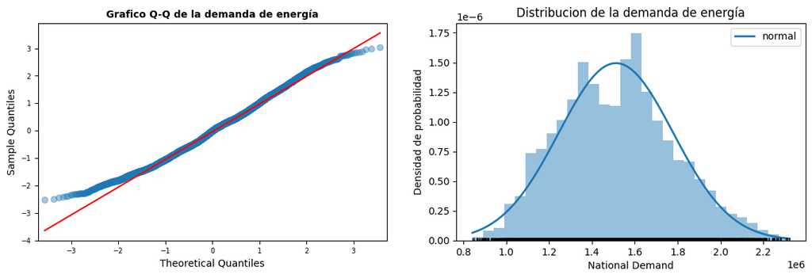

```python
demand=data["nd"]

fig,ax = plt.subplots(1,2,figsize=(14,4))
sm.qqplot(demand, fit= True, line  = "q", alpha = 0.4, lw= 2, ax= ax[0])
ax[0].set_title("Grafico Q-Q de la demanda de energía", fontsize = 10, fontweight ="bold")
ax[0].tick_params(labelsize = 7)

mu,sigma = stats.norm.fit(demand)

x_hat = np.linspace (min(demand),max(demand),num=100)
y_hat = stats.norm.pdf(x_hat, mu, sigma)

ax[1].plot(x_hat, y_hat, linewidth=2, label="normal")
ax[1].hist(x=demand,density=True, bins=30,color="#3182bd",alpha=0.5)
ax[1].plot(demand, np.full_like(demand, -0.01), '|k', markeredgewidth=1)
ax[1].set_title("Distribucion de la demanda de energía")
ax[1].set_xlabel("National Demand")
ax[1].set_ylabel("Densidad de probabilidad")
ax[1].legend()


print("Kursotis:", stats.kurtosis(demand))
print("Skewness:", stats.skew(demand))
print("Valores optimos entre -1 y 1")
```

El resultado es una distribución de probabilidad muy similar a una distribución teórica Gaussiana. Ambos valores de Kurtosis y Skewness están dentro de los parámetros óptimos. En caso de que estos valores estuviesen fuera de los intervalos, podríamos realizar una transformación box-cox sobre la variable de estudio para mejorar tanto la forma de las colas como la simetría de la distribución.

### Homocedasticidad

Ahora vamos a comprobar la heterocedasticidad de la variable a predecir, donde para ello simplemente podemos hacer un analisis de dispersion de la muestra y observar el comportamiento de la varianza respecto de la media en toda la serie temporal.

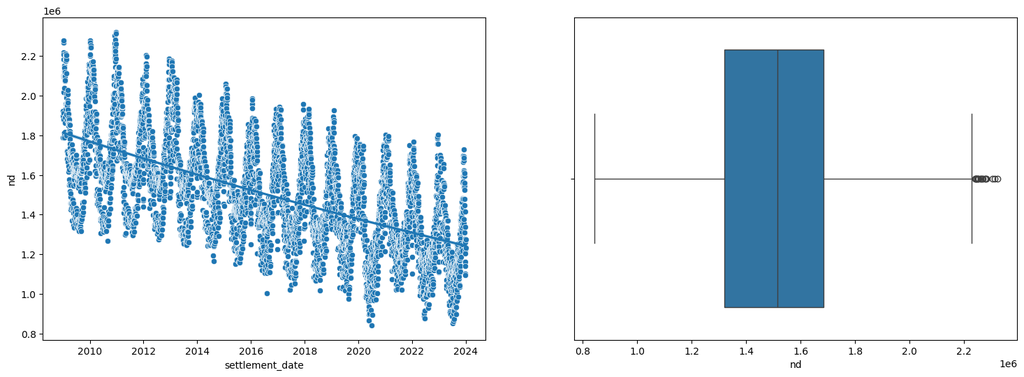

```python
f, ax = plt.subplots(1, 2, figsize=(18, 6))
ax[0].xaxis.update_units(data.index)

sns.scatterplot(
                data=data,
                x=data.index,
                y="nd",
                ax=ax[0]
                )
sns.regplot(
            data=data,
            x=ax[0].xaxis.convert_units(data.index),
            y=data['nd'],
            scatter=False,
            logx=True,
            ax=ax[0]
            )
sns.boxplot(
            x=data["nd"],
            ax=ax[1]
            )
```

A simple vista, podemos observar que se cumplen en cierto modo los supuestos de normalidad y homocedasticidad de la variable. Esto hará mucho mas sencillo los siguientes pasos.

## Análisis estacionario

Ahora, comprobaremos la temporalidad de la serie, en donde se puede apreciar una tendencia negativa. Mas tarde descomponemos la serie n su partes fundamentales donde llegamos a las siguientes conclusiones:

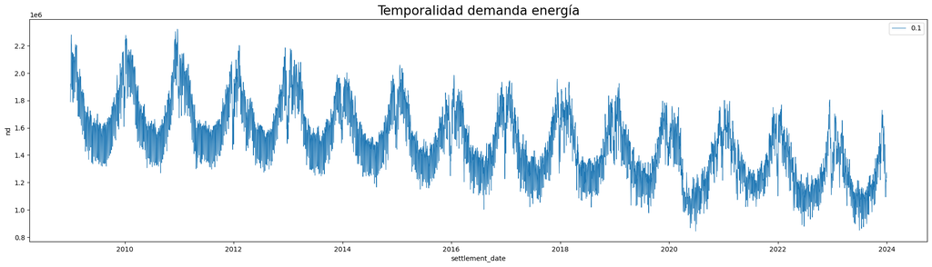

```python
fig, ax = plt.subplots(1,1,figsize=(24,6))
sns.lineplot(data=data,
             x=data.index,
             y="nd",
             size=0.1,
             ax=ax
             )
ax.set_title("Temporalidad demanda energía",fontsize=19)
```

```python
data_short = data[data.index.year == 2023]
```

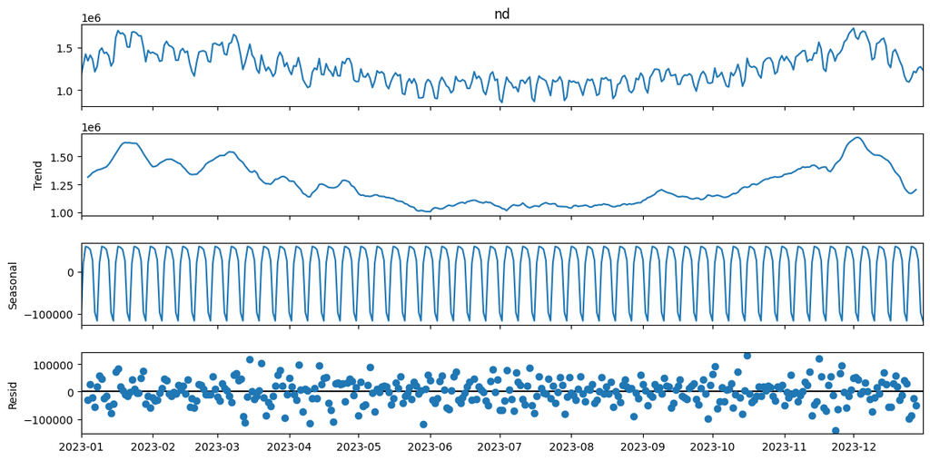

```python
result = seasonal_decompose(data_short["nd"], model="additive")
fig = result.plot()
fig.set_size_inches((12,6))
fig.tight_layout()
plt.show()
```

Visto la serie en gran escala y descompuesta a un year concreto, procedemos a ver el comportamiento de la muestra en una granularidad de mes y semana, con las siguientes conclusiones:

- A nivel mensual, la varianza es algo superior los meses de invierno. Aun asi el comportamiento entre meses tiene muchas similitudes
- A nivel semanal, la varianza entre días es calcada, teniendo los días de menor demanda en los últimos días de la semana

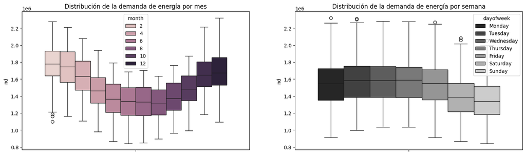

```python
data_months = data.copy()
data_months["month"] = data_months.index.month
data_months["dayofweek"] = data_months.index.day_name()

ordered_days = ['Monday', 'Tuesday', 'Wednesday', 'Thursday', 'Friday', 'Saturday', 'Sunday']


fig, ax = plt.subplots(1,2,figsize=(18,5))
sns.boxplot(
    data=data_months,
    y = "nd",
    hue = "month",
    ax=ax[0]
)
sns.boxplot(
    data=data_months,
    y = "nd",
    hue = "dayofweek",
    palette="dark:.8",
    hue_order=ordered_days,
    ax = ax[1]
)

ax[0].set_title("Distribución de la demanda de energía por mes")
ax[1].set_title("Distribución de la demanda de energía por semana")
```

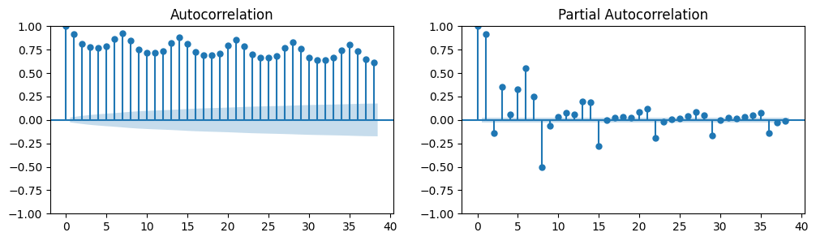

```python
fig, ax = plt.subplots(1,2,figsize=(12, 3))
plot_acf(data["nd"], ax=ax[0])
plot_pacf(data["nd"], ax=ax[1])
plt.show()
```